# Credit Scoring

Machine Learning Step

Felipe Daiha Alves

2022-09-12

# 1 . **Objetivo**:

Relatório da etapa de *machine learning* contendo fases de modelagem e avaliação de métricas sobre o processo de **Risco de Crédito** em empréstimos bancários.

O conjunto de dados original foi extraído de uma fonte pública e salvo localmente em um *csv* com os dados previamente tratados armazenados em um arquivo comprimido em *gz* com os dados para elaboração do modelo. Para acesso ao dicionário das variáveis, entre em https://github.com/daiha98/credit_scoring/blob/main/README.md.

# 2 . **Environment & Data Preparation**:

## 2.1 . **Configurando Ambiente**

```r
# Nome dos pacotes

packages <- c('openxlsx', 'dplyr', 'data.table', ## Manipulacao de Dados
              'ggplot2', 'ggraph', 'igraph', 'knitr', 'kableExtra', ## Visualizacao de Dados
               'caTools', 'caret', 'randomForest', 'xgboost', 'ROSE',  ## Algoritmos e Ferramentas de ML
               'mlr', 'DALEX', 'MLmetrics', 'mltools', 'miscTools' ## Avaliacao de resultados dos modelos
              )


# Instalando pacotes (caso ainda nao esteja)

installed_packages <- packages %in% rownames(installed.packages())
if (any(installed_packages == FALSE)) {
  install.packages(packages[!installed_packages])
}


# Carregando pacotes

invisible(lapply(packages, library, character.only = TRUE))


# Removendo variavel criada previamente

rm(packages, installed_packages)


# Configuracoes de visualizacao

options(digits = 10, scipen = 999)
```

## 2.2 . **Funções utilizadas**

```r
# Funcoes aplicadas neste markdown

    ## 1 - Configuracao dos parametros em pre-modelos no mlr

    mlrConfig <- function(learner, params){

      res = mlr::tuneParams(
        learner = mlr::makeLearner(learner, predict.type = "response"),
        task = mlr::makeClassifTask(data = train_db_balanced %>%
                                      dplyr::mutate(BAD = as.factor(BAD)), target = "BAD", positive = "0"),
        resampling = mlr::makeResampleDesc(method = "RepCV", folds = 5, reps = 3),
        control = mlr::makeTuneControlGrid(),
        par.set = params,
        measures = list(acc, fn, fp, tn, tp),
        show.info = FALSE)

      res

    }

    ## 2 - Visualizar os resultados do mlr

    resView <- function(tuneRes, modelName){

      opt_df = as.data.frame(tuneRes$opt.path) %>%
        dplyr::mutate(model = modelName) %>%
        dplyr::select(model, exec.time, acc.test.mean, fn.test.mean, fp.test.mean, tn.test.mean, tp.test.mean) %>%
        dplyr::mutate(PPV = (tp.test.mean)/(tp.test.mean + fn.test.mean),
                      NPV = (tn.test.mean)/(tn.test.mean + fp.test.mean))

      opt_df

    }

    ## 3 - table_view

    table_view <- function(tbl, title){

    # Printando tabela

    knitr::kable(tbl, caption = paste0("<b> ", title, " <b>"),
                 row.names = TRUE, align = 'c', longtable = T,
                 table.attr = "style='width:30%;'", format = 'html') %>%
      kableExtra::kable_styling(full_width = TRUE, position = "center") %>%
      kableExtra::row_spec(0, bold = TRUE)

    }

    ## 4 - confusion_matrix

    confusion_matrix <- function(obj, dataset){

      # Fazendo as previsoes em cima de test_db:

      prediction = stats::predict(
        object = obj,
        newdata = dataset %>% dplyr::select(!c(clientId)))


      # Matriz Confusao do modelo

      mc_result = table(as.data.frame(dataset)[, "BAD"],
                        as.data.frame(prediction)[, 1])

      caret::confusionMatrix(mc_result)

    }
```

## 2.3 . **Carregando dados**

```r
# Load da base de dados

CreditScoring <- data.table::fread('C:/Users/daiha/OneDrive/Documentos/R/CreditScoring_dfML.gz')


# Visualizacao primaria dos dados

glimpse(CreditScoring)
```

```
## Rows: 33,025
## Columns: 24
## $ clientId                             <int> 4, 5, 6, 7, 8, 9, 10, 11, 12, 14,…
## $ shopId                               <int> 12, 16, 24, 55, 6, 3, 23, 25, 12,…
## $ gender                               <chr> "F", "F", "M", "F", "F", "F", "F"…
## $ maritalStatus                        <chr> "C", "S", "S", "S", "C", "S", "C"…
## $ age                                  <int> 47, 28, 26, 22, 21, 27, 57, 53, 3…
## $ flagResidencialPhone                 <chr> "N", "Y", "N", "Y", "Y", "Y", "Y"…
## $ areaCodeResidencialPhone             <int> 31, 31, 31, 31, 23, 31, 31, 31, 3…
## $ bestPaymentDay                       <int> 25, 25, 28, 12, 28, 20, 12, 18, 1…
## $ shopRank                             <int> 0, 0, 0, 0, 0, 0, 0, 0, 0, 0, 0, …
## $ residenceType                        <chr> "P", "O", "P", "A", "A", "A", "P"…
## $ monthsInResidence                    <int> 180, 12, 180, 0, 24, 0, 24, 60, 2…
## $ flagMothersName                      <chr> "Y", "Y", "Y", "Y", "Y", "Y", "Y"…
## $ flagFathersName                      <chr> "Y", "Y", "Y", "Y", "Y", "Y", "Y"…
## $ flagResidenceTown_WorkingTown        <chr> "N", "Y", "N", "Y", "Y", "Y", "N"…
## $ flagResidenceState_WorkingState      <chr> "Y", "Y", "Y", "Y", "Y", "Y", "Y"…
## $ monthsInTheJob                       <int> 24, 12, 0, 48, 12, 0, 96, 24, 0, …
## $ professionCode                       <int> 35, 24, 999, 999, 40, 950, 13, 13…
## $ mateIncome                           <dbl> 0, 0, 0, 0, 800, 0, 0, 0, 0, 0, 0…
## $ flagResidencialAddress_PostalAddress <chr> "Y", "Y", "Y", "Y", "Y", "Y", "Y"…
## $ personalNetIncome                    <dbl> 304.0, 250.0, 800.0, 410.0, 248.0…
## $ BAD                                  <int> 0, 0, 0, 0, 0, 1, 0, 1, 0, 0, 0, …
## $ agesInResidence                      <int> 15, 1, 15, 0, 2, 0, 2, 5, 2, 10, …
## $ agesInTheJob                         <int> 2, 1, 0, 4, 1, 0, 8, 2, 0, 3, 1, …
## $ flag_mateIncome                      <int> 0, 0, 0, 0, 1, 0, 0, 0, 0, 0, 0, …
```

## 2.4 . **Feature Engineering**

**Seleção de Variáveis**

A análise exploratória verificou potenciais variáveis que pudessem discriminar bons e maus pagadores. Partindo disso, iremos selecionar as principais características para trabalharmos na etapa de **feature engineering** e futura composição do nosso modelo de ML. Manteremos *clientId* inicialmente para auxiliar no merge futuro de avaliação do modelo, mas obviamente não será aplicado na etapa de treino.

```r
# Criando copía do dataset

df_model <- CreditScoring


# Escolha das variaveis relevantes e convertendo classes de variaveis para melhor compreensao do algoritmo

df_model <- df_model %>%
  dplyr::select(clientId, age, agesInResidence, agesInTheJob, bestPaymentDay, personalNetIncome,
                BAD) %>%
  dplyr::mutate(BAD = as.factor(BAD))


# Dropando base original

rm(CreditScoring)
```

**Novas Features**

Podemos ainda cruzar variaveis segundo um racional. Por exemplo, multiplicar renda pelos anos trabalhados (*personalNetIncome* x 12 x *agesInTheJob*).

```r
# Cruzando features e dropando variaveis indesejadas

df_model <- df_model %>%
  dplyr::mutate(personalLifeIncome = personalNetIncome * 12 * agesInTheJob)

# Print de algumas linhas para verificacao

df_model %>%
  dplyr::select(clientId, personalLifeIncome) %>%
  dplyr::slice(1:5)
```

```
##    clientId personalLifeIncome
## 1:        4               7296
## 2:        5               3000
## 3:        6                  0
## 4:        7              19680
## 5:        8               2976
```

## 2.5 . **Machine Learning**

**Balanceamento de classes**

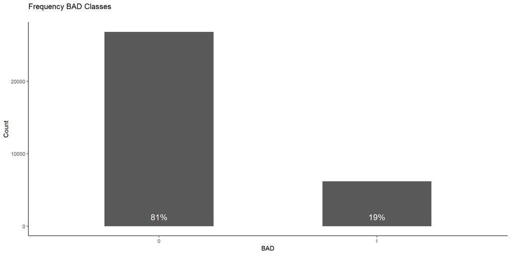

```r
# Gerando um grafico de frequencia absoluta para verificar o balanceamento das classes:

ggplot2::ggplot(df_model, aes(x = BAD)) +
  ggplot2::geom_bar(width = 0.5) +
  ggplot2::labs(title = "Frequency BAD Classes\n", x = 'BAD', y = 'Count') +
  ggplot2::theme_classic() +
  ggplot2::geom_text(aes(label = scales::percent((..count..)/sum(..count..)),
                         y= ((..count..)/sum(..count..))), stat="count",
                     vjust = -1, colour = "white", size = 5)
```

```r
# Em quantidade absoluta:

table(df_model$BAD)
```

```
##
##     0     1
## 26839  6186
```

*Comments*: Há um evidente desbalanceamento das classes da variável resposta. Devemos tratar para melhor generalização do modelo.

**Split de Treino & Teste**

Dividiremos nossa base em treino e teste para as etapas de modelagem e avaliação dos resultados, respectivamente, e verificamos se está devidamente balanceado as bases conforme as proporções vistas acima.

```r
# Criando a "semente geradora" e dividindo a Base de Dados em Treino-Teste:

set.seed(1234)

# Divide a base de dados aleatoriamente segundo a variavel 'X' em fracoes TRUE (75%) e FALSE (25%).

split_db = caTools::sample.split(df_model$BAD, SplitRatio = 0.75)

    ## Define que os valores TRUE pertencem ao DB treino

    train_db = base::subset(df_model, split_db == TRUE)

    ## Define que os valores FALSE pertencem ao DB teste

    test_db = base::subset(df_model, split_db == FALSE)

    ## Dropando variaveis indesejadas

    rm(split_db)


# Verificando se datasets estao balanceados

    ## 1 - Treino

    table_view(setDT(train_db)[,.N/nrow(train_db),BAD],
               title = "Balanceamento no dataset de Treino")
```

**Balanceamento no dataset de Treino**

|  | BAD | V1 |
| --- | --- | --- |
| 1 | 0 | 0.8126690621 |
| 2 | 1 | 0.1873309379 |

```r
    ## 2 - Teste

    table_view(setDT(test_db)[,.N/nrow(test_db),BAD],
               title = "Balanceamento no dataset de Teste")
```

**Balanceamento no dataset de Teste**

|  | BAD | V1 |
| --- | --- | --- |
| 1 | 0 | 0.8127422481 |
| 2 | 1 | 0.1872577519 |

*Comments*: Está balanceado proporcionalmente à base de dados original!

**Tratando desbalanceamento**

Para ajustar o desbalanceamento de classes, iremos promover a técnica de geração de dados sintéticos pelo método de **over-undersampling** do pacote *ROSE*.  
Criarmos demasiadamente dados sintéticos sobre características pouco discriminantes (visto na etapa de análise exploratória) podem confundir o algoritmo com comportamentos irreais dos registros.  
Porém, se apenas reduzirmos a classe majoritária para o total de registros da classe minoritária, iremos simplesmente descartar dados reais que podem ser relevante pra sua interpretação final.  
Portanto, a decisão de utilizar *over-undersampling* em detrimento dos demais métodos foi priorizada.

```r
# Utilizando o recurso de geracao de dados sinteticos para classificacoes binarias de
# classes desbalanceadas do pacote 'ROSE'

train_db_balanced = ROSE::ovun.sample(
  BAD ~ .,
  data = train_db %>%
    dplyr::select(!c(clientId)),
  seed = 1234, method = "both")$data


# Verificando a distribuicao

table_view(table(train_db_balanced$BAD),
           title = "Distribuição do Target após Rebalanceamento")
```

**Distribuição do Target após Rebalanceamento**

|  | Var1 | Freq |
| --- | --- | --- |
| 1 | 0 | 12251 |
| 2 | 1 | 12518 |

**Testando alguns modelos**

Segundo a composição do nosso dataset e as fracas variáveis discriminatórias visualmente falando, serão testados modelos ensamble do tipo árvores para estudos de algortimos a serem aplicados. Pela análise exploratória, já se espera um modelo com baixas métricas de avaliação.  
Nosso objetivo aqui é construir um modelo conservador, que consiga detectar uma alta taxa de maus pagadores, mas que consiga também predizer acima de 50% dos bons pagadores, para que justifique o trabalho futuro de produtização. Não existe certo ou errado nesses casos, vai de acordo com o modelo de negócio que se quer implementar.

```r
# Modelos e parametros iniciais a serem otimizados para posterior analise

    ## 1 - Random Forest

          ### Armazenando numeros para hiperparametros

          nT = 50
          mTr = floor(sqrt(ncol(train_db_balanced) - 1))
          nSz = floor(sqrt(nrow(train_db_balanced) - (nrow(train_db_balanced)/5)))

          ### Utilizando funcao previamente criada para elaboracao das metricas

          res <- mlrConfig(learner = "classif.randomForest",
                           params = ParamHelpers::makeParamSet(
                             makeDiscreteParam("ntree", values = nT),
                             makeDiscreteParam("mtry", values = mTr),
                             makeDiscreteParam("nodesize", values = nSz)))

          ### Visualizando resultados do tuning

          opt_RF = resView(tuneRes = res, modelName = 'randFor')

    ## 2 - XG Boost

          ### Valores para os parametros

          nR = 50
          mDp = floor(sqrt(ncol(train_db_balanced) - 1))
          eta = 0.1

          ### Funcao mlrConfig para retirada das metricas

          res <- mlrConfig(learner = "classif.xgboost",
                           params = ParamHelpers::makeParamSet(
                             makeDiscreteParam("nrounds", values = nR),
                             makeDiscreteParam("max_depth", values = mDp),
                             makeDiscreteParam("eta", values = eta)))

          ### Visualizando resultados do tuning

          opt_XG = resView(tuneRes = res, modelName = 'xgBoost')


# Juntando tudo em um mesmo df e printando na tela

view <- data.table::rbindlist(list(opt_RF, opt_XG), use.names = TRUE, fill = TRUE)

table_view(view, "Comparativo entre Pré-Modelos")
```

**Comparativo entre Pré-Modelos**

|  | model | exec.time | acc.test.mean | fn.test.mean | fp.test.mean | tn.test.mean | tp.test.mean | PPV | NPV |
| --- | --- | --- | --- | --- | --- | --- | --- | --- | --- |
| 1 | randFor | 18.77 | 0.6574483172 | 937.8000000 | 759.1333333 | 1744.466667 | 1512.400000 | 0.6172557342 | 0.6967832987 |
| 2 | xgBoost | 5.22 | 0.6039404666 | 999.2666667 | 962.7333333 | 1540.866667 | 1450.933333 | 0.5921693467 | 0.6154604037 |

*Comments*: Os modelos apresentam performances similares. O que podemos parcialmente concluir é que o XgBoost é relativamente mais rápido e apresentou resultados mais próximos de PPV (Positive Predicted Value) & NPV (Negative Predicted Value)  
Nessa fase, foram testados apenas um conjunto de hiperparâmetros, pois queríamos buscar análises superficiais em relação aos algoritmos escolhidos.

**Treinamento XGBoost**

Com nosso modelo selecionado, partiremos para sua construção. Setamos os argumentos de controle do treinamento e outros parâmetros para a função de treino.

```r
# Construindo modelo de classificacao

xg_model <- caret::train(BAD ~ .,
                         data = train_db_balanced,
                         preProcess = c("scale"),
                         trControl = caret::trainControl(
                           method = 'repeatedcv', number = 5, repeats = 2,
                           search = "grid", allowParallel = TRUE),
                         metric = "Accuracy", maximize = TRUE,
                         tuneGrid = expand.grid(
                           nrounds = nR,
                           eta = eta,
                           max_depth = mDp,
                           gamma = 0,
                           colsample_bytree = 1,
                           min_child_weight = 1,
                           subsample = 1),
                         method = "xgbTree",
                         verbose = FALSE,
                         verbosity = 0)

# Printando output do modelo

print(xg_model)
```

[output not shown]

## 2.6 . **Métricas de Avaliação**

**Escorando datasets**

Modelo devidamente treinado, parte-se para a escoragem dos conjuntos de dados de treino e teste. Esta etapa é imprescindível para analisar as principais métricas de avaliação dos modelos e identificar possível overfitting na etapa de treinamento do algoritmo.

```r
# Fazendo as previsoes em cima de train_db:

confusion_matrix(obj = xg_model, dataset = train_db)
```

```
## Confusion Matrix and Statistics
##
##
##         0     1
##   0 11945  8184
##   1  1790  2850
##
##                Accuracy : 0.5973192
##                  95% CI : (0.5911802, 0.6034354)
##     No Information Rate : 0.5545238
##     P-Value [Acc > NIR] : < 0.00000000000000022204
##
##                   Kappa : 0.1357005
##
##  Mcnemar's Test P-Value : < 0.00000000000000022204
##
##             Sensitivity : 0.8696760
##             Specificity : 0.2582926
##          Pos Pred Value : 0.5934224
##          Neg Pred Value : 0.6142241
##              Prevalence : 0.5545238
##          Detection Rate : 0.4822560
##    Detection Prevalence : 0.8126691
##       Balanced Accuracy : 0.5639843
##
##        'Positive' Class : 0
##
```

*Comments*: Nossos resultados na base de treino acompanharam o esperado. Baixas métricas de avaliação dado o fraco poder de discriminação das features.  
Porém, as métricas de PPV e NPV estão equilibradas e acima do limiar objetivo, o que nos satisfaz até o momento.  
Agora, partiremos para a análise no conjunto de teste.

```r
# Fazendo as previsoes em cima de test_db:

confusion_matrix(obj = xg_model, dataset = test_db)
```

```
## Confusion Matrix and Statistics
##
##
##        0    1
##   0 4001 2709
##   1  602  944
##
##                Accuracy : 0.5989583
##                  95% CI : (0.5882924, 0.6095544)
##     No Information Rate : 0.5575339
##     P-Value [Acc > NIR] : 0.00000000000001531678
##
##                   Kappa : 0.1357111
##
##  Mcnemar's Test P-Value : < 0.00000000000000022204
##
##             Sensitivity : 0.8692157
##             Specificity : 0.2584177
##          Pos Pred Value : 0.5962742
##          Neg Pred Value : 0.6106080
##              Prevalence : 0.5575339
##          Detection Rate : 0.4846172
##    Detection Prevalence : 0.8127422
##       Balanced Accuracy : 0.5638167
##
##        'Positive' Class : 0
##
```

*Comments*: Da mesma forma, no conjunto de teste as métricas permaneceram próximas e também com uma Specificidade muito baixa, mostrando uma tendência do algoritmo em classificar Falsos Negativos.  
Dado o que se quer propor, acabou que foi uma das métricas menos prejudicial de ser impactada, visto nosso objetivo conservador nesta régua de concessão de crédito.

**Feature Importance**

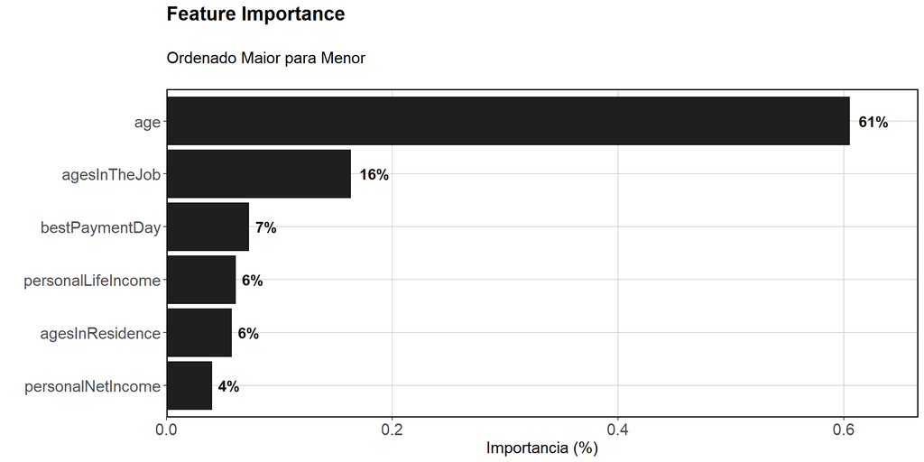

```r
# Elaborando plot para analise

ggplot2::ggplot(
  data = as.data.frame(
    xgboost::xgb.importance(xg_model$finalModel$feature_names,
                            model=xg_model$finalModel)),
  aes(x = reorder(Feature, Gain), y = Gain)) +
  ggplot2::geom_col(fill = '#1E1E1E', colour = '#111111') +
  ggplot2::coord_flip() +
  ggplot2::labs(title = "Feature Importance\n",
                subtitle = "Ordenado Maior para Menor\n") +
  ggplot2::xlab(' ') +
  ggplot2::scale_y_continuous("Importancia (%)", expand = expansion(c(0, 0.1))) +
  ggplot2::geom_text(aes(
    label = paste0(round(Gain*100, 0), '%')),
    hjust = - 0.3,
    colour = '#111111',
    fontface = 'bold',
    size = 5.0) +
  ggplot2::theme(
    panel.background = element_rect(fill = "white"),
    panel.grid.major.y =  element_line(colour = "lightgrey"),
    panel.grid.major.x =  element_line(colour = "lightgrey"),
    plot.title = element_text(size = 18, face = "bold"),
    plot.subtitle = element_text(size = 15.0),
    panel.border = element_rect(colour = "black", fill = NA, size = 1),
    axis.text.x = element_text(angle = 0, size = 15.0),
    axis.text.y = element_text(size = 15.0),
    axis.title.x = element_text(size = 15.0),
    axis.title.y = element_text(size = 15.0))
```

**ROC Curve**

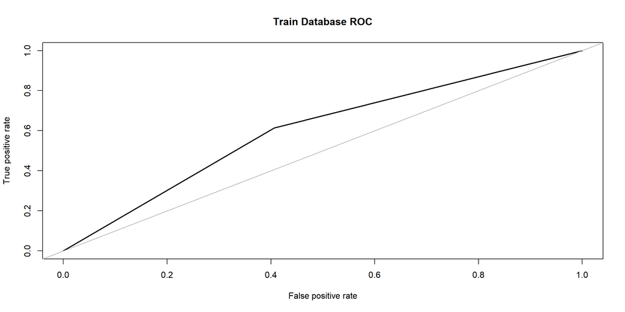

```
## Area under the curve (AUC): 0.604
```

```r
# Plot da curva

  ## Treino:

      ROSE::roc.curve(train_db$BAD,
                      stats::predict(object = xg_model, newdata = train_db),
                      main = "Train Database ROC",
                      plotit = TRUE)
```

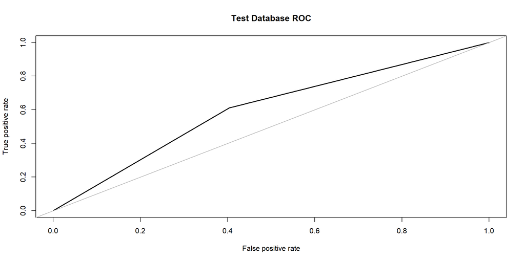

```
## Area under the curve (AUC): 0.603
```

```r
  ## Teste:

      ROSE::roc.curve(test_db$BAD,
                      stats::predict(object = xg_model, newdata = test_db),
                      main = "Test Database ROC",
                      plotit = TRUE)
```

## 2.7 . **Conclusão**

O resultado atingido foi um modelo considerado **Conservador**!  
Como a base de dados é relativamente desbalanceada e os dados fornecidos são, ao meu ver, **insuficientes** para se chegar a um modelo que obtivesse alta precisão e acurácia com equilíbrio nas classes, o modelo de machine learning elaborado foi **mais direcionado a acertar a classe 1**, ou seja, de clientes inadimplentes. Afinal, este cliente é considerado um prejuízo para a instituição financeira.  
Então no cenário existente, foi mais importante acertar o devedor do que o pagador.